# Problem Set 2

MGSC 310

Jaime Song

## Question 1: Predicting Movie Revenue

Part 1: Data Splitting

```r
data(movies)
movies <- read_csv("datasets/IMDB_movies.csv")
movies %>% glimpse()
```

```
## Rows: 3,889
## Columns: 25
## $ movie_title               <chr> "Avatar", "Pirates of the Caribbea…
## $ director_name             <chr> "James Cameron", "Gore Verbinski",…
## $ gross                     <dbl> 760505847, 309404152, 200074175, 4…
## $ budget                    <dbl> 237000000, 300000000, 245000000, 2…
## $ country                   <chr> "USA", "USA", "UK", "USA", "USA", …
## $ title_year                <dbl> 2009, 2007, 2015, 2012, 2012, 2007…
## $ imdb_score                <dbl> 7.9, 7.1, 6.8, 8.5, 6.6, 6.2, 7.8,…
## $ language                  <chr> "English", "English", "English", "…
## $ duration                  <dbl> 178, 169, 148, 164, 132, 156, 100,…
## $ genres                    <chr> "Action|Adventure|Fantasy|Sci-Fi",…
## $ content_rating            <chr> "PG-13", "PG-13", "PG-13", "PG-13"…
## $ aspect_ratio              <dbl> 1.78, 2.35, 2.35, 2.35, 2.35, 2.35…
## $ color                     <chr> "Color", "Color", "Color", "Color"…
## $ plot_keywords             <chr> "avatar|future|marine|native|parap…
## $ movie_facebook_likes      <dbl> 33000, 0, 85000, 164000, 24000, 0,…
## $ director_facebook_likes   <dbl> 0, 563, 0, 22000, 475, 0, 15, 0, 2…
## $ cast_total_facebook_likes <dbl> 4834, 48350, 11700, 106759, 1873, …
## $ facenumber_in_poster      <dbl> 0, 0, 1, 0, 1, 0, 1, 4, 3, 0, 0, 1…
## $ actor_1_facebook_likes    <dbl> 1000, 40000, 11000, 27000, 640, 24…
## $ actor_1_name              <chr> "CCH Pounder", "Johnny Depp", "Chr…
## $ actor_2_facebook_likes    <dbl> 936, 5000, 393, 23000, 632, 11000,…
## $ actor_2_name              <chr> "Joel David Moore", "Orlando Bloom…
## $ num_user_for_reviews      <dbl> 3054, 1238, 994, 2701, 738, 1902, …
## $ num_critic_for_reviews    <dbl> 723, 302, 602, 813, 462, 392, 324,…
## $ num_voted_users           <dbl> 886204, 471220, 275868, 1144337, 2…
```

```r
movies_clean <-
  movies %>%
  mutate(budgetM = budget/1000000,
         grossM = gross/1000000,
         profitM = grossM - budgetM,
         ROI = profitM/budgetM,
         genre_main = as.factor(unlist(map(strsplit(as.character(movies$genres),"\\|"),1))) %>% fct_lump(12),
         rating_simple = fct_lump(content_rating, n = 6)
         ) %>%
  filter(budget < 400000000,
         content_rating != "",
         content_rating != "Not Rated",
         language == "English") %>%
  mutate(rating_simple = rating_simple %>% fct_drop()) %>%
  rename(director = director_name,
         title = movie_title,
         year = title_year) %>%
  select(-c(actor_1_name, actor_2_name,actor_1_facebook_likes, actor_2_facebook_likes,
         budget, gross, aspect_ratio, num_voted_users,num_user_for_reviews)) %>%
  relocate(title, year, country, director, budgetM, grossM, profitM, ROI, imdb_score, genre_main, rating_simple, language, duration)

set.seed(310)
movies_split <- initial_split(movies_clean, prop = 0.80)
movies_train <- training(movies_split)
movies_test <- testing(movies_split)
```

Part 2: Linear Regression

```r
movies_train$rating_simple <- relevel(movies_train$rating_simple, ref = "R")
model1 <- lm(grossM ~ imdb_score + budgetM + rating_simple, movies_train)
summary(model1)
```

```
##
## Call:
## lm(formula = grossM ~ imdb_score + budgetM + rating_simple, data = movies_train)
##
## Residuals:
##     Min      1Q  Median      3Q     Max
## -370.68  -26.00   -8.28   16.17  484.03
##
## Coefficients:
##                       Estimate Std. Error t value
## (Intercept)          -94.69468    6.21756 -15.230
## imdb_score            15.61448    0.92700  16.844
## budgetM                0.97327    0.02316  42.029
## rating_simpleG        33.74727    6.34817   5.316
## rating_simpleMissing -11.70681   10.41910  -1.124
## rating_simplePG       23.26882    2.88223   8.073
## rating_simplePG-13    17.14975    2.27851   7.527
## rating_simpleOther     3.86416    8.39777   0.460
##                                  Pr(>|t|)
## (Intercept)          < 0.0000000000000002 ***
## imdb_score           < 0.0000000000000002 ***
## budgetM              < 0.0000000000000002 ***
## rating_simpleG       0.000000114004112602 ***
## rating_simpleMissing                0.261
## rating_simplePG      0.000000000000000989 ***
## rating_simplePG-13   0.000000000000068827 ***
## rating_simpleOther                  0.645
## ---
## Signif. codes:  0 '***' 0.001 '**' 0.01 '*' 0.05 '.' 0.1 ' ' 1
##
## Residual standard error: 51.56 on 2930 degrees of freedom
## Multiple R-squared:  0.4878, Adjusted R-squared:  0.4866
## F-statistic: 398.6 on 7 and 2930 DF,  p-value: < 0.00000000000000022
```

```r
# The Multiple R-squared is 0.4878, meaning about 48.78% of the variance in grossM is explained by the predictors (imdb_score, budgetM, and rating_simple)

# The Adjusted R-squared is 0.4866, which is slighly lower but still close, indicating that the adding predictors has improved the model without overfitting
```

Part 3: Interpretation

BudgetM Coefficient Interpretation: The coefficient for budgetM is 0.97327 meaning that for each additional million dollars spent on a movie, the expected gross revenue increases by $0.97 million on average. Spending more does not necessarily mean greater net profit. A higher budget correlates with higher revenue but it does not account for costs. For example, if a movie spends an extra $10 million, it is expected to earn about $9.73 million more in revenue, which is a negative return on investment. Therefore, higher spending does not always guarantee higher net profit.

Rating Interpretation: The coefficient for rating_simpleG is 33.75 meaning that on average G-rated movies earn $33.75 million more in revenue than R-rated movies, assuming all other factors are the same. This suggests that G-rated movies tend to have a broader audience appeal, leading to higher box office revenues compared to R-rated movies, which have a restricted audience.

P-value Explanation: The p-value for imdb_score is < 0.0000000000000002 which is extremely small. A p-value measures the probability of observing a relationship this strong between imdb_score and revenue purely by chance, assuming there is actually no true relationship. A very small p-value (< 0.05) means we have strong evidence to reject the null hypothesis. Since the p-value is so small, we can conclude with high confidence that imdb_score has a statistically significant positive relationship with revenue. Therefore, higher IMDb scores are strongly associated with higher box office earnings.

Part 4: Prediction and Evaluation

```r
grossM_train <- predict(model1, newdata = movies_train)
RMSE(grossM_train, movies_train$grossM)
```

```
## [1] 51.48504
```

```r
grossM_test <- predict(model1, newdata = movies_test)
RMSE(grossM_test, movies_test$grossM)
```

```
## [1] 50.24709
```

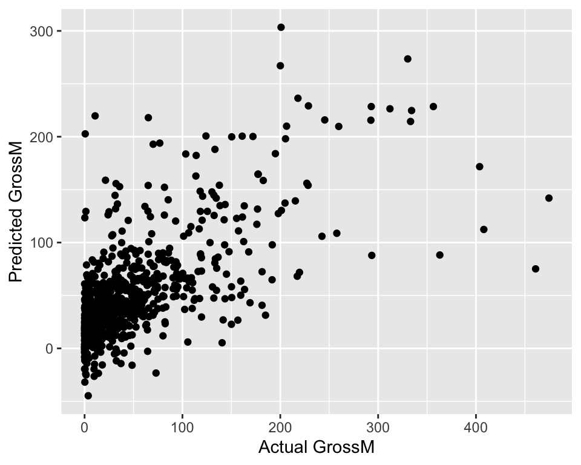

```r
results_test <- data.frame(
  preds = grossM_test,
  actual = movies_test$grossM
)

# create a scatter plot for actual vs predicted
ggplot(results_test, aes(x = actual, y = preds)) +
  geom_point() +
  xlab("Actual GrossM") +
  ylab("Predicted GrossM")
```

Part 5: Reflection

One specific limitation of the model is that it does not account for marketing and distribution factors, which can have a major impact on a movie’s revenue. A movie with a moderate budget but strong marketing might outperform a high-budget film with poor promotion. One way to improve this model could be to integatre the variable movie_facebook_likes to understand how audience anticipation correlates with box office performance.